# Linking Spi-B and PU.1 binding sites to genes

Holly Giles

30 March 2022

Make the figures and analysis solid in here, then move into supplement and figure 4, and tell Peter, Sascha and Wolfgang Aim to do as much of this today as I can, so that tomorrow is for text and other htigns

1. get out correct peaks [x]
2. Optimise coverage plot <- almost there, just make sure x scale is appropriate and final check [x]
3. Try adding Ibet peaks on top of that (adapt .id part of function)
4. use function to get three genes.
5. Optimise GSEa
6. optimse GSEA plot
7. Add back in

= good progress now

Carry on with this anlaysis tomorrow morning Then use Ivan’s analyses in afternoon THen Wednesday put things into text and rebuttal Then carry on with other ranomd things after esp on Firday

This is an rmd to identify SPIB and PU.1 peaks that are differentially accessible between tri12 and WT CLL, and to link these to downstream genes.

# 1 Set up

Load libraries

```r
################# load libraries #################

library(readr)
library(dplyr)
library(tidyverse)
library(ChIPseeker)
library(TxDb.Hsapiens.UCSC.hg19.knownGene)
library(GenomicRanges)
library("org.Hs.eg.db")
library(clusterProfiler)
library(ggpubr)
library(magrittr)
library(patchwork)
library(ggplotify)
library(msigdbr)
library(GenomicRanges)
```

Set plot directory

```r
plotDir = ifelse(exists(".standalone"), "", "../../inst/figs/")
if(plotDir!="") if(!file.exists(plotDir)) dir.create(plotDir)
```

## 1.1 Load data

Load raw files

```r
#df: tibble containing all screening viability data
peaklfc <- read_tsv("../data/BIGCLL52.SPIB.output.tsv.gz")
peaklfc_ibet <- read_tsv("../data/IBETvsCTRL.SPIB.0.A.output.tsv.gz")

peaklfcbackup <- peaklfc

peaklfc %>% data.table::as.data.table()
```

```
##       permutation   TF  chr       MSS       MES                   TFBSID strand
##    1:           0 SPIB chr1  10011057  10011269   chr1:10011057-10011269      +
##    2:           0 SPIB chr1 100173152 100173364 chr1:100173152-100173364      +
##    3:           0 SPIB chr1 100232089 100232301 chr1:100232089-100232301      -
##    4:           0 SPIB chr1 100259552 100259764 chr1:100259552-100259764      -
##    5:           0 SPIB chr1 100512474 100512686 chr1:100512474-100512686      -
##   ---
## 5557:           0 SPIB chr9  95987789  95988001   chr9:95987789-95988001      -
## 5558:           0 SPIB chr9   9612454   9612666     chr9:9612454-9612666      -
## 5559:           0 SPIB chr9  96338051  96338263   chr9:96338051-96338263      +
## 5560:           0 SPIB chr9  97431486  97431698   chr9:97431486-97431698      -
## 5561:           0 SPIB chr9  98257455  98257667   chr9:98257455-98257667      +
##                         peakID    l2FC limma_avgExpr limma_B limma_t_stat
##    1:   chr1:10010293-10011410 -0.3960            NA      NA           NA
##    2: chr1:100173127-100173479 -0.2000            NA      NA           NA
```

[output cut: 21 more lines]

## 1.2 Define Aesthetics

```r
source("../R/themes_colors.R")
```

## 1.3 Define Functions

```r
#sort chr by number
sortChrName <- function(chr.name) {
    ## X, Y and M will cause warnings when change to number.
    noChr <- suppressWarnings(as.numeric(sub("chr", "", chr.name)))
    ## index of chromosome name are character, such as X, Y
    ch.idx <- which(is.na(noChr))

    n.idx <- which(!is.na(noChr))
    chr.n <- noChr[n.idx]

    chr.sorted <- chr.name[n.idx][order(chr.n)]
    if (length(ch.idx) != 0) {
        chr.sorted <- c(chr.sorted, sort(chr.name[ch.idx]))
    }

    return(chr.sorted)
}
```

# 2 Spi-B binding sites

Find top peaks

```r
#filter for top peaks (all or up)
TFBS <- peaklfc %>% dplyr::filter(abs(l2FC) >1, pval_adj <0.1)


#remove Chr
TFBS <- TFBS %>%
        #remove chr string
        mutate_at(vars(TFBSID), list(~as.character(gsub("chr.*:", "", .)))) %>%
        #separate into start and end
        separate(TFBSID, c("start", "end"))
```

Convert to a genomic ranges object

```r
peak<-
  TFBS %>%
  dplyr::select(TF, chr, start, end, strand, l2FC, pval,  pval_adj) %>%
  makeGRangesFromDataFrame(keep.extra.columns = TRUE)
```

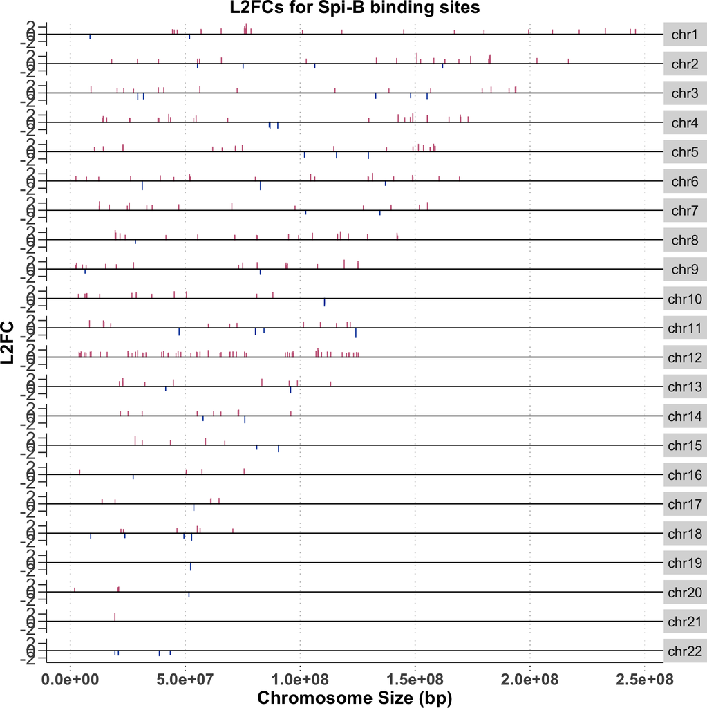

```r
#get a dataframe of all SPIB binding sites that show sig Log2FC
peak_df <-
  TFBS %>%
  dplyr::select(TF, chr, start, end, strand, l2FC, pval,  pval_adj)

#make factors / numeric
chr.sorted <- unique(sortChrName(peak_df$chr))
peak_df$chr <- factor(peak_df$chr, levels = chr.sorted)
peak_df$start <- as.numeric(peak_df$start)
peak_df$end <- as.numeric(peak_df$end)


p <- ggplot(peak_df, aes(start, l2FC))+
  geom_rect(aes(xmin = start, ymin = 0, xmax = end, ymax = l2FC,
                color = ifelse(l2FC<0, palreds[5], palblues[1]),
                fill= ifelse(l2FC<0, palreds[5], palblues[1]))) +
  scale_fill_manual(values = c(palreds[5], palblues[1]), guide = "none") +
  scale_color_manual(values = c(palreds[5], palblues[1]), guide = "none") +
  facet_grid(chr ~ ., scales = "fixed", space = "fixed")+
  xlab("Chromosome Size (bp)") +
  ylab("L2FC") +
  ggtitle("L2FCs for Spi-B binding sites")+
  t2 + theme(strip.text.y = element_text(angle = 360)) +
  ylim(-3, 3) +
  geom_hline(yintercept=0)



p
```

# 3 Spi-B binding sites and IBET binding sties

Find top peaks

```r
#filter for all SPIB sites that are downregulated by IBET treatment
TFBS_IBET <- peaklfc_ibet %>% dplyr::filter(l2FC <0)

#filter for all SPIB sites that are upregulated in tri12
TFBS_up <- peaklfc %>% dplyr::filter(l2FC>0)


#remove Chr
TFBS_IBET <- TFBS_IBET %>%
        #remove chr string
        mutate_at(vars(TFBSID), list(~as.character(gsub("chr.*:", "", .)))) %>%
        #separate into start and end
        separate(TFBSID, c("start", "end"))


TFBS_up <- TFBS_up %>%
        #remove chr string
        mutate_at(vars(TFBSID), list(~as.character(gsub("chr.*:", "", .)))) %>%
        #separate into start and end
        separate(TFBSID, c("start", "end"))
```

Convert to a genomic ranges object

```r
peak_IBET <-
  TFBS_IBET %>%
  dplyr::select(TF, chr, start, end, strand, l2FC, pval,  pval_adj) %>%
  makeGRangesFromDataFrame(keep.extra.columns = TRUE)

peak_up <-
  TFBS_up %>%
  dplyr::select(TF, chr, start, end, strand, l2FC, pval,  pval_adj) %>%
  makeGRangesFromDataFrame(keep.extra.columns = TRUE)
```

```r
#get a dataframe of all SPIB binding sites that show sig Log2FC
peak_IBET_df <-
  TFBS_IBET %>%
  dplyr::select(TF, chr, start, end, strand, l2FC, pval,  pval_adj)

peak_up_df <-
  TFBS_up %>%
  dplyr::select(TF, chr, start, end, strand, l2FC, pval,  pval_adj)

#make factors / numeric
chr.sorted <- unique(sortChrName(peak_IBET_df$chr))
peak_IBET_df$chr <- factor(peak_IBET_df$chr, levels = chr.sorted)
peak_IBET_df$start <- as.numeric(peak_IBET_df$start)
peak_IBET_df$end <- as.numeric(peak_IBET_df$end)

chr.sorted <- unique(sortChrName(peak_up_df$chr))
peak_up_df$chr <- factor(peak_up_df$chr, levels = chr.sorted)
peak_up_df$start <- as.numeric(peak_up_df$start)
peak_up_df$end <- as.numeric(peak_up_df$end)

#check how many peaks overlap
#cehck how many Spi-B binding sites change with IBET treatment
#3326 SPIb sites are upregulated in tri 12
#SPIB sites are downregulated by IBET
#36 of these overlap = this isnt a very specific effect

peak_up
```

```
## GRanges object with 3326 ranges and 4 metadata columns:
##          seqnames              ranges strand |          TF      l2FC      pval
##             <Rle>           <IRanges>  <Rle> | <character> <numeric> <numeric>
##      [1]     chr1 100259552-100259764      - |        SPIB    0.7150  2.43e-02
##      [2]     chr1 100512474-100512686      - |        SPIB    0.0343  8.39e-01
##      [3]     chr1 100650209-100650421      - |        SPIB    0.2700  2.60e-01
##      [4]     chr1 100731693-100731905      - |        SPIB    0.0502  6.91e-01
##      [5]     chr1 100988665-100988877      - |        SPIB    1.0200  3.32e-06
##      ...      ...                 ...    ... .         ...       ...       ...
##   [3322]     chr9   94483174-94483386      - |        SPIB    1.3500  0.000508
##   [3323]     chr9   95532791-95533003      + |        SPIB    0.6230  0.021800
##   [3324]     chr9   95805470-95805682      + |        SPIB    0.0838  0.727000
##   [3325]     chr9   97431486-97431698      - |        SPIB    0.3470  0.335000
##   [3326]     chr9   98257455-98257667      + |        SPIB    0.3050  0.666000
##           pval_adj
##          <numeric>
##      [1]  0.119000
##      [2]  0.936000
##      [3]  0.516000
##      [4]  0.856000
##      [5]  0.000237
##      ...       ...
##   [3322]   0.00918
##   [3323]   0.11200
##   [3324]   0.87400
##   [3325]   0.58700
##   [3326]   0.84000
##   -------
##   seqinfo: 22 sequences from an unspecified genome; no seqlengths
```

```r
subsetByOverlaps(peak_up, peak_IBET)
```

```
## GRanges object with 36 ranges and 4 metadata columns:
##        seqnames              ranges strand |          TF      l2FC      pval
##           <Rle>           <IRanges>  <Rle> | <character> <numeric> <numeric>
##    [1]    chr12 110894389-110894601      - |        SPIB    0.2520    0.2380
##    [2]    chr18   10482984-10483196      + |        SPIB    0.0397    0.8620
##    [3]    chr18   12200215-12200427      - |        SPIB    0.6450    0.0459
##    [4]    chr18     3660849-3661061      + |        SPIB    0.1210    0.6400
##    [5]    chr18     9113483-9113695      + |        SPIB    0.1940    0.2470
##    ...      ...                 ...    ... .         ...       ...       ...
##   [32]     chr9     4842230-4842442      + |        SPIB     0.409  2.93e-01
##   [33]     chr9     5536814-5537026      - |        SPIB     0.729  3.86e-02
##   [34]     chr9       657255-657467      - |        SPIB     0.386  4.08e-01
##   [35]     chr9     6703969-6704181      - |        SPIB     0.217  3.80e-01
##   [36]     chr9     6889984-6890196      - |        SPIB     1.020  5.40e-06
##         pval_adj
##        <numeric>
##    [1]     0.490
##    [2]     0.947
##    [3]     0.179
##    [4]     0.825
##    [5]     0.501
##    ...       ...
##   [32]  0.547000
##   [33]  0.160000
##   [34]  0.651000
##   [35]  0.627000
##   [36]  0.000337
##   -------
##   seqinfo: 22 sequences from an unspecified genome; no seqlengths
```

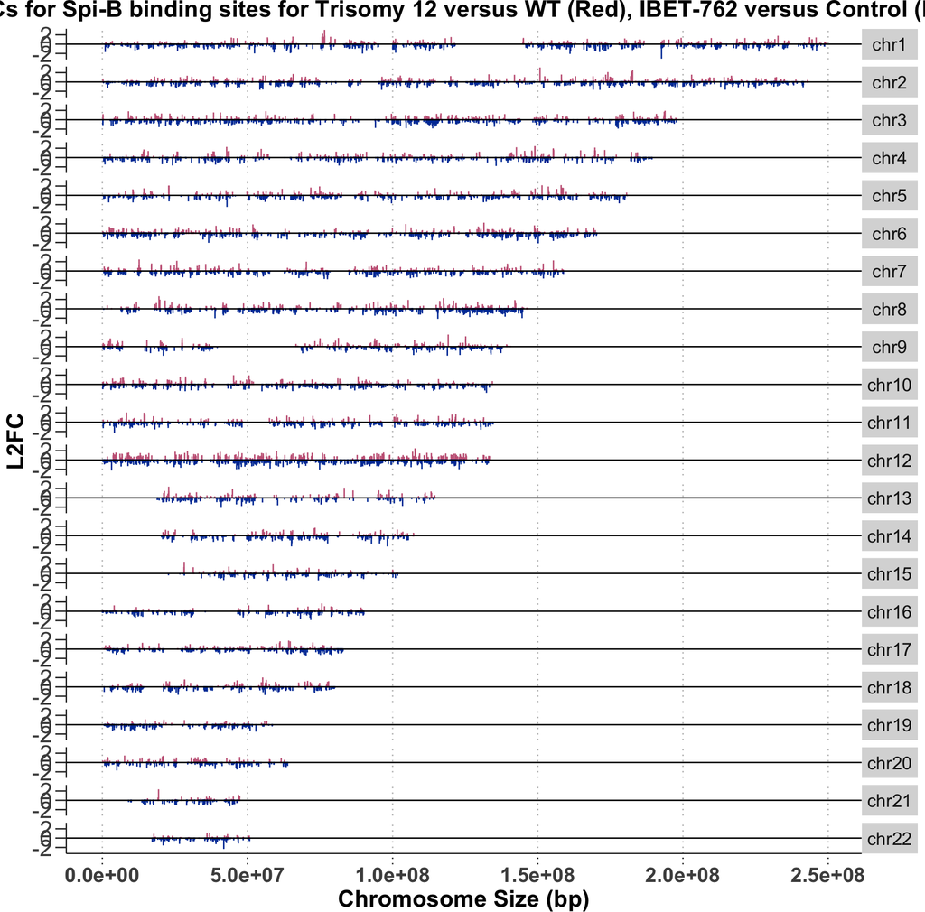

```r
#add column to denote origin
peak_up_df$condition <- "tri12"
peak_IBET_df$condition <- "ibet"

#merge dataframes
all_peaks <- rbind(peak_up_df, peak_IBET_df)


#plot both sets of peaks
q <- ggplot(all_peaks, aes(start, l2FC))+
  geom_rect(aes(xmin = start, ymin = 0, xmax = end, ymax = l2FC,
                color = condition)) +
  scale_color_manual(values = c( palblues[1], palreds[5]), guide = "none") +
  facet_grid(chr ~ ., scales = "fixed", space = "fixed")+
  xlab("Chromosome Size (bp)") +
  ylab("L2FC") +
  ggtitle("L2FCs for Spi-B binding sites for Trisomy 12 versus WT (Red), IBET-762 versus Control (Blue)")+
  t2 + theme(strip.text.y = element_text(angle = 360)) +
  ylim(-3, 3) +
  geom_hline(yintercept=0)



q
```

# Peak annotation

Annotate peaks

Here I use the annotatePeak function to find nearest gene to each of my SPIB binding sites, looking in the region ±3kb around the tss sites defined in the TxDB object. The resulting `peakAnno` object contains all the original information on my SPIB bding sites, along with information on the annotation of these sites (eg promoter/Exon/intron/intergenic) and the nearest gene and its function.

```r
#get annotation database
txdb <- TxDb.Hsapiens.UCSC.hg19.knownGene

#annoate all genes within 5kb
peakAnno <- annotatePeak(peak,
                         tssRegion=c(-3000, 3000), #region in whcih to look for genes
                         TxDb=txdb, #define where to get transcript info
                         annoDb="org.Hs.eg.db", addFlankGeneInfo = TRUE) #set annotation package to add ensembl, smbol and genames
```

```
## >> preparing features information...      2022-03-30 13:38:52
## >> identifying nearest features...        2022-03-30 13:38:53
## >> calculating distance from peak to TSS...   2022-03-30 13:38:54
## >> assigning genomic annotation...        2022-03-30 13:38:54
## >> adding gene annotation...          2022-03-30 13:40:06
```

```
## >> adding flank feature information from peaks...     2022-03-30 13:40:07
## >> assigning chromosome lengths           2022-03-30 13:40:09
## >> done...                    2022-03-30 13:40:09
```

```r
#peakAnno is a csAnno onject - can convert:
as.data.frame(peakAnno) %>%
  DT::datatable()
```

|  | seqnames | start | end | width | strand | TF | l2FC | pval | pval_adj | annotation | geneChr | geneStart | geneEnd | geneLength | geneStrand | geneId | transcriptId | distanceToTSS | ENSEMBL | SYMBOL | GENENAME | flank_txIds | flank_geneIds | flank_gene_distances |
| --- | --- | --- | --- | --- | --- | --- | --- | --- | --- | --- | --- | --- | --- | --- | --- | --- | --- | --- | --- | --- | --- | --- | --- | --- |
| 1 | chr1 | 100988665 | 100988877 | 213 | - | SPIB | 1.02 | 3.32e-06 | 0.000237 | Distal Intergenic | 1 | 101003728 | 101007583 | 3856 | 1 | 54112 | uc001dth.3 | -15063 | ENSG00000181656 | GPR88 | G protein-coupled receptor 88 | uc001dtg.4;uc009wee.3 | 8556;8556 | 170642;170642 |
| 2 | chr1 | 118138734 | 118138946 | 213 | + | SPIB | 1.13 | 0.000202 | 0.00491 | Distal Intergenic | 1 | 118148604 | 118171011 | 22408 | 1 | 54855 | uc001ehe.3 | -9658 | ENSG00000183508 | TENT5C | terminal nucleotidyltransferase 5C |  |  |  |
| 3 | chr1 | 145030091 | 145030303 | 213 | + | SPIB | 1.2 | 4.78e-05 | 0.00167 | Intron (uc021ott.2/100288142, intron 53 of 131) | 1 | 144676437 | 145039992 | 363556 | 2 | 653513 | uc001elm.4 | 9689 |  | LOC653513 | phosphodiesterase 4D interacting protein-like | uc021ott.2;uc021ots.1;uc010oye.3;uc031pnx.1;uc001elm.4;uc001eln.4;uc001elo.3;uc001elx.4;uc001emh.3 | 100288142;100288142;400818;400818;653513;653513;9659;9659;9659 | 0;0;0;0;0;0;0;0;0 |
| 4 | chr1 | 167059959 | 167060171 | 213 | + | SPIB | 1.01 | 3.28e-05 | 0.00124 | Promoter (&lt;=1kb) | 1 | 167022082 | 167059868 | 37787 | 2 | 10223 | uc001gea.1 | -91 | ENSG00000143167 | GPA33 | glycoprotein A33 | uc001gea.1;uc001geb.1 | 10223;92235 | -91;-3900 |
| 5 | chr1 | 179942913 | 179943125 | 213 | - | SPIB | 1.08 | 0.00255 | 0.0266 | Intron (uc001gnr.1/9857, intron 1 of 4) | 1 | 179955316 | 180080330 | 125015 | 1 | 9857 | uc009wxl.2 | -12403 | ENSG00000135837 | CEP350 | centrosomal protein 350 | uc001gnr.1;uc001gnt.3 | 9857;9857 | 0;0 |
| 6 | chr1 | 199369545 | 199369757 | 213 | - | SPIB | 1.21 | 0.00874 | 0.0611 | Distal Intergenic | 1 | 198777132 | 198906558 | 129427 | 2 | 100131234 | uc021pgz.1 | -463199 |  | MIR181A1HG | MIR181A1 host gene |  |  |  |
| 7 | chr1 | 209743073 | 209743285 | 213 | - | SPIB | 1.17 | 0.0018 | 0.0212 | Distal Intergenic | 1 | 209757045 | 209787284 | 30240 | 1 | 57172 | uc001hhd.3 | -13972 | ENSG00000008118 | CAMK1G | calcium/calmodulin dependent protein kinase IG |  |  |  |
| 8 | chr1 | 221340280 | 221340492 | 213 | + | SPIB | 1.18 | 2.09e-06 | 0.000171 | Distal Intergenic | 1 | 221503270 | 221509638 | 6369 | 2 | 400804 | uc001hmw.1 | 169146 | ENSG00000234754 | LINC02817 | long intergenic non-protein coding RNA 2817 |  |  |  |
| 9 | chr1 | 232726546 | 232726758 | 213 | + | SPIB | 1.66 | 0.00201 | 0.0229 | Distal Intergenic | 1 | 232533712 | 232651243 | 117532 | 2 | 57568 | uc001hvg.3 | -75303 | ENSG00000116991 | SIPA1L2 | signal induced proliferation associated 1 like 2 |  |  |  |
| 10 | chr1 | 243615502 | 243615714 | 213 | - | SPIB | 1.35 | 0.000901 | 0.0132 | Intron (uc001hzw.3/10806, intron 16 of 17) | 1 | 243509478 | 243509557 | 80 | 1 | 100616343 | uc021plt.1 | 106236 | ENSG00000265201 | MIR4677 | microRNA 4677 | uc001hzw.3;uc010pyk.2;uc010pyl.2;uc001hzx.3 | 10806;10806;10806;10806 | 0;0;0;0 |

[output cut: 365 more lines]

## 3.1 Enrichment of selected pathways

```r
#get  KEGG pathways from msigdbr database
kegg <-
  msigdbr(species = "Homo sapiens", category = "C2", subcategory = "CP:KEGG") %>%
  #select pathway name and entrez id
  dplyr::select(gs_name, entrez_gene)


#subset for pathways that we want to test
kegg <-
  dplyr::filter(kegg,
         #All KEGG immune signaling pathways
         gs_name %in% c("KEGG_B_CELL_RECEPTOR_SIGNALING_PATHWAY",
                        "KEGG_CHEMOKINE_SIGNALING_PATHWAY",
                        "KEGG_CYTOKINE_CYTOKINE_RECEPTOR_INTERACTION",
                        "KEGG_JAK_STAT_SIGNALING_PATHWAY" ,
                        "KEGG_NOD_LIKE_RECEPTOR_SIGNALING_PATHWAY"  ,
                        "KEGG_NOTCH_SIGNALING_PATHWAY",
                        "KEGG_RIG_I_LIKE_RECEPTOR_SIGNALING_PATHWAY",
                        "KEGG_TOLL_LIKE_RECEPTOR_SIGNALING_PATHWAY",
                        "KEGG_T_CELL_RECEPTOR_SIGNALING_PATHWAY",
                        #Control genesets
                        "KEGG_OXIDATIVE_PHOSPHORYLATION",
                        "KEGG_DNA_REPLICATION"
         ))

colnames(kegg) <- c("term", "gene")

#tidy up terms - remove KEGG, underscore and put in lower cases
kegg$term <- gsub("KEGG_", "",kegg$term )
kegg$term <- gsub("_", " ",kegg$term )
kegg$term <- gsub("B CELL RECEPTOR SIGNALING PATHWAY",
                  "BCR Signaling Pathway",kegg$term )
kegg$term <- gsub("CHEMOKINE SIGNALING PATHWAY",
                  "Chemokine Signaling Pathway",kegg$term )
kegg$term <- gsub("CYTOKINE CYTOKINE RECEPTOR INTERACTION",
                  "Cytokine Cytokine Receptor Interaction",kegg$term )
kegg$term <- gsub("JAK STAT SIGNALING PATHWAY",
                  "JAK STAT signaling pathway",kegg$term )
kegg$term <- gsub("NOD LIKE RECEPTOR SIGNALING PATHWAY",
                  "NLR Signaling Pathway",kegg$term )
kegg$term <- gsub("NOTCH SIGNALING PATHWAY",
                  "Notch Signaling Pathway",kegg$term )
kegg$term <- gsub("RIG I LIKE RECEPTOR SIGNALING PATHWAY",
                  "RLR Signaling Pathway",kegg$term )
kegg$term <- gsub("TOLL LIKE RECEPTOR SIGNALING PATHWAY",
                  "TLR Signaling Pathway",kegg$term )

kegg$term <- gsub("T CELL RECEPTOR SIGNALING PATHWAY",
                  "TCR Signaling Pathway",kegg$term )
kegg$term <- gsub("OXIDATIVE PHOSPHORYLATION",
                  "Oxidative Phosphorylation",kegg$term )
kegg$term <- gsub("P53 SIGNALING PATHWAY",
                  "P53 Signaling Pathway",kegg$term )
kegg$term <- gsub("DNA REPLICATION",
                  "DNA Replication",kegg$term )

kegg$genesetDatabase <- "KEGG"


#get reactome pathways
reactome <-
  msigdbr(species = "Homo sapiens", category = "C2", subcategory = "CP:REACTOME") %>%
  #select pathway name and entrez id
  dplyr::select(gs_name, entrez_gene)

#subset for pathways that we want to test
reactome <-
  dplyr::filter(reactome,
         gs_name %in% c(#selected immune pathways
                        "REACTOME_SIGNALING_BY_TGF_BETA_RECEPTOR_COMPLEX",
                        "REACTOME_TNF_SIGNALING",
                        "REACTOME_INTERLEUKIN_1_SIGNALING",
                        "REACTOME_INTERLEUKIN_10_SIGNALING",
                        "REACTOME_INTERLEUKIN_15_SIGNALING",
                        "REACTOME_INTERLEUKIN_2_SIGNALING",
                        "REACTOME_INTERLEUKIN_4_AND_INTERLEUKIN_13_SIGNALING",
                        "REACTOME_INTERLEUKIN_6_SIGNALING" ,
                        "REACTOME_OTHER_INTERLEUKIN_SIGNALING",
                        "REACTOME_SIGNALING_BY_INTERLEUKINS",
                        "REACTOME_INTERFERON_ALPHA_BETA_SIGNALING" ,
                        "REACTOME_INTERFERON_GAMMA_SIGNALING",
                        #Control genesets
                        "REACTOME_CELL_CYCLE",
                        "REACTOME_REGULATION_OF_TP53_ACTIVITY"
                        ))

colnames(reactome) <- c("term", "gene")

#tidy up terms
reactome$term <- gsub("REACTOME_", "",reactome$term )
reactome$term <- gsub("_", " ",reactome$term )


#tidy up and put in lower case
reactome$term <- gsub("CELL CYCLE",
                      "Cell Cycle",reactome$term )
reactome$term <- gsub("INTERLEUKIN 1 SIGNALING",
                      "Interleukin 1 Signaling",reactome$term )
reactome$term <- gsub("INTERLEUKIN 10 SIGNALING",
                      "Interleukin 10 Signaling",reactome$term )
reactome$term <- gsub("INTERLEUKIN 15 SIGNALING",
                      "Interleukin 15 Signaling",reactome$term )
reactome$term <- gsub("INTERLEUKIN 2 SIGNALING",
                      "Interleukin 2 Signaling",reactome$term )
reactome$term <- gsub("INTERLEUKIN 4 AND INTERLEUKIN 13 SIGNALING",
                      "Interleukin 4 and Interleukin 13 Signaling",reactome$term )
reactome$term <- gsub("INTERLEUKIN 6 SIGNALING",
                      "Interleukin 6 Signaling",reactome$term )
reactome$term <- gsub("OTHER INTERLEUKIN SIGNALING",
                      "Other Interleukin Signaling",reactome$term )
reactome$term <- gsub("SIGNALING BY INTERLEUKINS",
                      "Signaling by Interleukins",reactome$term )
reactome$term <- gsub("REGULATION OF TP53 ACTIVITY",
                      "Regulation of TP53 Pathway",reactome$term )
reactome$term <- gsub("SIGNALING BY TGF BETA RECEPTOR COMPLEX",
                      # "Signaling by TGFbeta \nReceptor Complex", reactome$term )
                      "Signaling by TGFbeta Receptor Complex", reactome$term )
reactome$term <- gsub("TNF SIGNALING",
                      "TNF Signaling",reactome$term )
reactome$term <- gsub("INTERFERON ALPHA BETA SIGNALING",
                      "Interferon Alpha Beta Signaling",reactome$term )

reactome$term <- gsub("INTERFERON GAMMA SIGNALING",
                      "Interferon Gamma Signaling", reactome$term )

#annotate which database these pathways come from
reactome$genesetDatabase <- "Reactome"
```

### 3.1.1 Single gene annotation

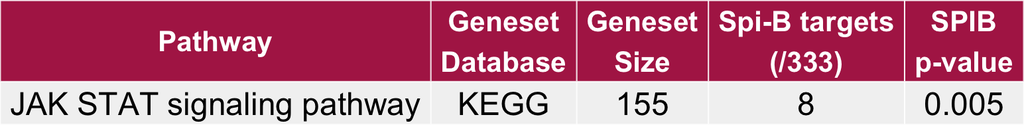

```r
#generate TERM2GENE dataframe to use in overrepresetation test
#join kegg and reactome gene sets together - this defines the list of pathways we are interested in, and select term and gene columns
term2gene <- rbind(kegg, reactome) %>% dplyr::select(term, gene)

#term2genesetdatabase - keep details of database source for each pathway
term2genesetdatabase <- rbind(kegg, reactome) %>% dplyr::select(term, genesetDatabase)
colnames(term2genesetdatabase) <- c("term", "name")

##SPIB
#run over-representation test, and extract all results and p values:
#NB Bg ratio = number of genes in set / number of unique genes in term2gene,
#NB Gene ratio = number of SPIB targets in gene set being tested / total number of SPIB targets that overlap with genes in term to gene

spibRes <- enricher(unique(as.data.frame(peakAnno)$geneId),
                    #Use pathways in term2gene
                    TERM2GENE=term2gene,
                    #assign description for each term, as its database source
                    TERM2NAME = term2genesetdatabase,
                    #no cutoffs on reported results, we want to see all results and p values
                    minGSSize = 0,
                    maxGSSize = 1000,
                    pvalueCutoff = 1,
                    qvalueCutoff = 1)


#get dataframe of results
spibRes.df <- fortify(spibRes,
              showCategory = length(unique(term2gene$term)), #show all pathways tested
              split=NULL)

resTab.spib <-
  mutate(spibRes.df, genesetSize = BgRatio*length(unique(term2gene$gene))) %>%  #multiply BgRatio by total genes tested to get number of genes in set
  dplyr::select(ID, Description, pvalue, Count, genesetSize)

colnames(resTab.spib) <- c("ID", "genesetDatabase", "pvalue_SPIB","count_SPIB", "genesetSize")


resTab <- resTab.spib

#where count and p value is NA, put a 0 / 1 (ie there were no SPIB target genes in the set)
resTab$count_SPIB[is.na(resTab$count_SPIB)] <- 0

resTab$pvalue_SPIB[is.na(resTab$pvalue_SPIB)] <- 1

#select columns of interest to show in figure
resTab <- dplyr::select(resTab, ID, genesetDatabase, genesetSize,  count_SPIB, pvalue_SPIB)

#adjust decimal places of p values
resTab$pvalue_SPIB <- round(resTab$pvalue_SPIB, digits = 3)

#get significant results
resTab <- dplyr::filter(resTab, pvalue_SPIB<0.05)

colnames(resTab) <- c("Pathway",
                      "Geneset\nDatabase" ,
                      "Geneset\nSize",

                      #show the total number of SPIB targets in ChIPseq data
                      paste("Spi-B targets\n(/" ,length(unique(as.data.frame(peakAnno)$geneId)),")", sep= ""),
                      "SPIB\np-value")

selectedPathways <-
ggtexttable(resTab, rows = NULL,
           theme = ttheme(
             colnames.style = colnames_style(color = "white", fill = palreds[7], size = 16),
             tbody.style = tbody_style(color = "black",size = 18)
           )
)


selectedPathways
```

### 3.1.2 All flanking genes

```r
#get all genes including flanking genes
#get flanking genes as a list
newpeakAnno <-
  as.data.frame(peakAnno) %>%
  separate(flank_geneIds, c("A", "B", "C", "D", "E", "F", "G", "H", "I"), ";")
```

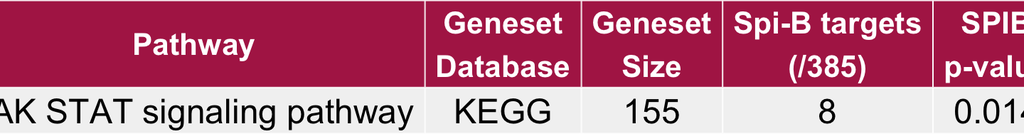

```r
#get column as a vector
geneList<- c(newpeakAnno$geneId, newpeakAnno$A, newpeakAnno$B, newpeakAnno$C, newpeakAnno$D, newpeakAnno$E, newpeakAnno$F, newpeakAnno$G, newpeakAnno$H, newpeakAnno$I)

#remove NAs
geneList <- geneList[!is.na(geneList)]

#remove duplicates
geneList <- unique(geneList)

spibRes <- enricher(geneList,
                    #Use pathways in term2gene
                    TERM2GENE=term2gene,
                    #assign description for each term, as its database source
                    TERM2NAME = term2genesetdatabase,
                    #no cutoffs on reported results, we want to see all results and p values
                    minGSSize = 0,
                    maxGSSize = 1000,
                    pvalueCutoff = 1,
                    qvalueCutoff = 1)


#get dataframe of results
spibRes.df <- fortify(spibRes,
              showCategory = length(unique(term2gene$term)), #show all pathways tested
              split=NULL)

resTab.spib <-
  mutate(spibRes.df, genesetSize = BgRatio*length(unique(term2gene$gene))) %>%  #multiply BgRatio by total genes tested to get number of genes in set
  dplyr::select(ID, Description, pvalue, Count, genesetSize)

colnames(resTab.spib) <- c("ID", "genesetDatabase", "pvalue_SPIB","count_SPIB", "genesetSize")


resTab <- resTab.spib

#where count and p value is NA, put a 0 / 1 (ie there were no SPIB target genes in the set)
resTab$count_SPIB[is.na(resTab$count_SPIB)] <- 0

resTab$pvalue_SPIB[is.na(resTab$pvalue_SPIB)] <- 1

#select columns of interest to show in figure
resTab <- dplyr::select(resTab, ID, genesetDatabase, genesetSize,  count_SPIB, pvalue_SPIB)

#adjust decimal places of p values
resTab$pvalue_SPIB <- round(resTab$pvalue_SPIB, digits = 3)

#get significant results
resTab <- dplyr::filter(resTab, pvalue_SPIB<0.05)

colnames(resTab) <- c("Pathway",
                      "Geneset\nDatabase" ,
                      "Geneset\nSize",

                      #show the total number of SPIB targets in ChIPseq data
                      paste("Spi-B targets\n(/" ,length(geneList),")", sep= ""),
                      "SPIB\np-value")

selectedPathways_allGenes <-
ggtexttable(resTab, rows = NULL,
           theme = ttheme(
             colnames.style = colnames_style(color = "white", fill = palreds[7], size = 16),
             tbody.style = tbody_style(color = "black",size = 18)
           )
)


selectedPathways_allGenes
```

## 3.2 Enrichment of all KEGG and Reactome

```r
#get  KEGG pathways from msigdbr database
kegg <-
  msigdbr(species = "Homo sapiens", category = "C2", subcategory = "CP:KEGG") %>%
  #select pathway name and entrez id
  dplyr::select(gs_name, entrez_gene)

#subset for pathways that we want to test

colnames(kegg) <- c("term", "gene")

#tidy up terms - remove KEGG, underscore and put in lower cases
kegg$term <- gsub("KEGG_", "",kegg$term )
kegg$term <- gsub("_", " ",kegg$term )


kegg$genesetDatabase <- "KEGG"


#get reactome pathways
reactome <-
  msigdbr(species = "Homo sapiens", category = "C2", subcategory = "CP:REACTOME") %>%
  #select pathway name and entrez id
  dplyr::select(gs_name, entrez_gene)

#subset for pathways that we want to test
colnames(reactome) <- c("term", "gene")

#tidy up terms
reactome$term <- gsub("REACTOME_", "",reactome$term )
reactome$term <- gsub("_", " ",reactome$term )


#annotate which database these pathways come from
reactome$genesetDatabase <- "Reactome"
```

### 3.2.1 Single gene annotation

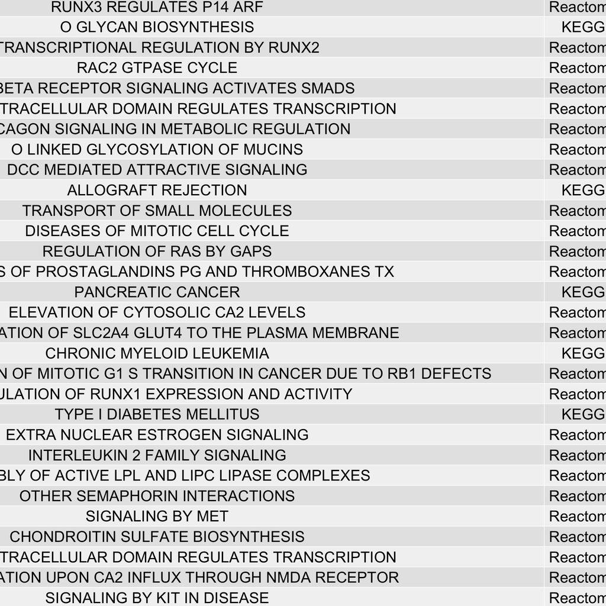

```r
#generate TERM2GENE dataframe to use in overrepresetation test
#join kegg and reactome gene sets together - this defines the list of pathways we are interested in, and select term and gene columns
term2gene <- rbind(kegg, reactome) %>% dplyr::select(term, gene)

#term2genesetdatabase - keep details of database source for each pathway
term2genesetdatabase <- rbind(kegg, reactome) %>% dplyr::select(term, genesetDatabase)
colnames(term2genesetdatabase) <- c("term", "name")

##SPIB
#run over-representation test, and extract all results and p values:
#NB Bg ratio = number of genes in set / number of unique genes in term2gene,
#NB Gene ratio = number of SPIB targets in gene set being tested / total number of SPIB targets that overlap with genes in term to gene

spibRes <- enricher(unique(as.data.frame(peakAnno)$geneId),
                    #Use pathways in term2gene
                    TERM2GENE=term2gene,
                    #assign description for each term, as its database source
                    TERM2NAME = term2genesetdatabase,
                    #no cutoffs on reported results, we want to see all results and p values
                    minGSSize = 0,
                    maxGSSize = 1000,
                    pvalueCutoff = 1,
                    qvalueCutoff = 1)


#get dataframe of results
spibRes.df <- fortify(spibRes,
              showCategory = length(unique(term2gene$term)), #show all pathways tested
              split=NULL)

resTab.spib <-
  mutate(spibRes.df, genesetSize = BgRatio*length(unique(term2gene$gene))) %>%  #multiply BgRatio by total genes tested to get number of genes in set
  dplyr::select(ID, Description, pvalue, Count, genesetSize)

colnames(resTab.spib) <- c("ID", "genesetDatabase", "pvalue_SPIB","count_SPIB", "genesetSize")


resTab <- resTab.spib

#where count and p value is NA, put a 0 / 1 (ie there were no SPIB target genes in the set)
resTab$count_SPIB[is.na(resTab$count_SPIB)] <- 0

resTab$pvalue_SPIB[is.na(resTab$pvalue_SPIB)] <- 1

#select columns of interest to show in figure
resTab <- dplyr::select(resTab, ID, genesetDatabase, genesetSize,  count_SPIB, pvalue_SPIB)

#adjust decimal places of p values
resTab$pvalue_SPIB <- round(resTab$pvalue_SPIB, digits = 3)

#get significant results
resTab <- dplyr::filter(resTab, pvalue_SPIB<0.05)

colnames(resTab) <- c("Pathway",
                      "Geneset\nDatabase" ,
                      "Geneset\nSize",

                      #show the total number of SPIB targets in ChIPseq data
                      paste("Spi-B targets\n(/" ,length(unique(as.data.frame(peakAnno)$geneId)),")", sep= ""),
                      "SPIB\np-value")

allPathways <-
ggtexttable(resTab, rows = NULL,
           theme = ttheme(
             colnames.style = colnames_style(color = "white", fill = palreds[7], size = 16),
             tbody.style = tbody_style(color = "black",size = 18)
           )
)


allPathways
```

### 3.2.2 All flanking genes

```r
#generate TERM2GENE dataframe to use in overrepresetation test
#join kegg and reactome gene sets together - this defines the list of pathways we are interested in, and select term and gene columns
term2gene <- rbind(kegg, reactome) %>% dplyr::select(term, gene)

#term2genesetdatabase - keep details of database source for each pathway
term2genesetdatabase <- rbind(kegg, reactome) %>% dplyr::select(term, genesetDatabase)
colnames(term2genesetdatabase) <- c("term", "name")

#get all genes including flanking genes
#get flanking genes as a list
newpeakAnno <-
  as.data.frame(peakAnno) %>%
  separate(flank_geneIds, c("A", "B", "C", "D", "E", "F", "G", "H", "I"), ";")
```

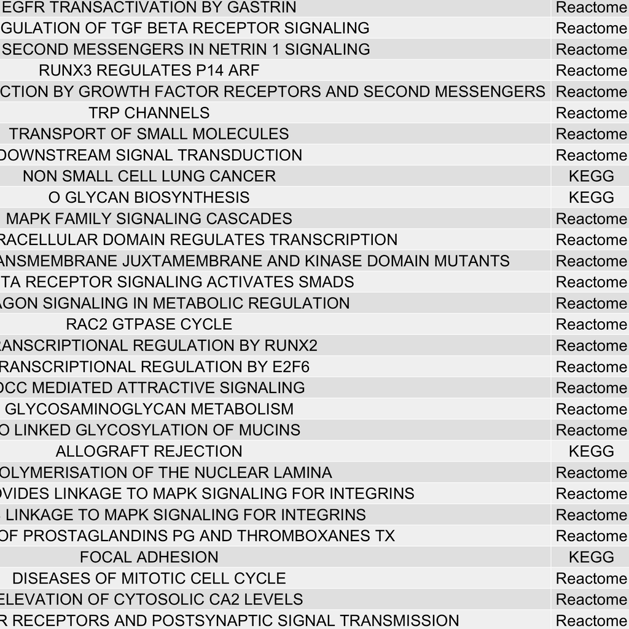

```r
#get column as a vector
geneList<- c(newpeakAnno$geneId, newpeakAnno$A, newpeakAnno$B, newpeakAnno$C, newpeakAnno$D, newpeakAnno$E, newpeakAnno$F, newpeakAnno$G, newpeakAnno$H, newpeakAnno$I)

#remove NAs
geneList <- geneList[!is.na(geneList)]

#remove duplicates
geneList <- unique(geneList)

##SPIB
#run over-representation test, and extract all results and p values:
#NB Bg ratio = number of genes in set / number of unique genes in term2gene,
#NB Gene ratio = number of SPIB targets in gene set being tested / total number of SPIB targets that overlap with genes in term to gene

spibRes <- enricher(geneList,
                    #Use pathways in term2gene
                    TERM2GENE=term2gene,
                    #assign description for each term, as its database source
                    TERM2NAME = term2genesetdatabase,
                    #no cutoffs on reported results, we want to see all results and p values
                    minGSSize = 0,
                    maxGSSize = 1000,
                    pvalueCutoff = 1,
                    qvalueCutoff = 1)


#get dataframe of results
spibRes.df <- fortify(spibRes,
              showCategory = length(unique(term2gene$term)), #show all pathways tested
              split=NULL)

resTab.spib <-
  mutate(spibRes.df, genesetSize = BgRatio*length(geneList)) %>%  #multiply BgRatio by total genes tested to get number of genes in set
  dplyr::select(ID, Description, pvalue, Count, genesetSize)

colnames(resTab.spib) <- c("ID", "genesetDatabase", "pvalue_SPIB","count_SPIB", "genesetSize")


resTab <- resTab.spib

#where count and p value is NA, put a 0 / 1 (ie there were no SPIB target genes in the set)
resTab$count_SPIB[is.na(resTab$count_SPIB)] <- 0

resTab$pvalue_SPIB[is.na(resTab$pvalue_SPIB)] <- 1

#select columns of interest to show in figure
resTab <- dplyr::select(resTab, ID, genesetDatabase, genesetSize,  count_SPIB, pvalue_SPIB)

#adjust decimal places of p values
resTab$pvalue_SPIB <- round(resTab$pvalue_SPIB, digits = 3)

#get significant results
resTab <- dplyr::filter(resTab, pvalue_SPIB<0.05)

colnames(resTab) <- c("Pathway",
                      "Geneset\nDatabase" ,
                      "Geneset\nSize",

                      #show the total number of SPIB targets in ChIPseq data
                      paste("Spi-B targets\n(/" ,length(geneList),")", sep= ""),
                      "SPIB\np-value")

allPathways <-
ggtexttable(resTab, rows = NULL,
           theme = ttheme(
             colnames.style = colnames_style(color = "white", fill = palreds[7], size = 16),
             tbody.style = tbody_style(color = "black",size = 18)
           )
)


allPathways
```

## 3.3 Only KEGG pathways

```r
#get  KEGG pathways from msigdbr database
kegg <-
  msigdbr(species = "Homo sapiens", category = "C2", subcategory = "CP:KEGG") %>%
  #select pathway name and entrez id
  dplyr::select(gs_name, entrez_gene)


#subset for pathways that we want to test

colnames(kegg) <- c("term", "gene")

#tidy up terms - remove KEGG, underscore and put in lower cases
kegg$term <- gsub("KEGG_", "",kegg$term )
kegg$term <- gsub("_", " ",kegg$term )


kegg$genesetDatabase <- "KEGG"
```

### 3.3.1 Single gene annotation

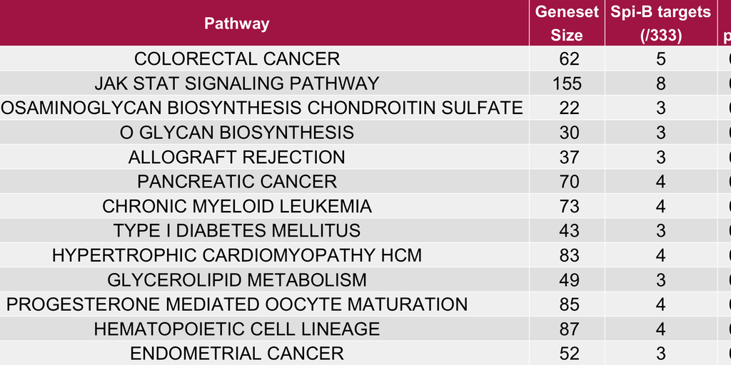

```r
#generate TERM2GENE dataframe to use in overrepresetation test
#join kegg and reactome gene sets together - this defines the list of pathways we are interested in, and select term and gene columns
term2gene <- kegg %>% dplyr::select(term, gene)

##SPIB
#run over-representation test, and extract all results and p values:
#NB Bg ratio = number of genes in set / number of unique genes in term2gene,
#NB Gene ratio = number of SPIB targets in gene set being tested / total number of SPIB targets that overlap with genes in term to gene

spibRes <- enricher(unique(as.data.frame(peakAnno)$geneId),
                    #Use pathways in term2gene
                    TERM2GENE=term2gene,
                    #no cutoffs on reported results, we want to see all results and p values
                    minGSSize = 0,
                    maxGSSize = 1000,
                    pvalueCutoff = 1,
                    qvalueCutoff = 1)


#get dataframe of results
spibRes.df <- fortify(spibRes,
              showCategory = length(unique(term2gene$term)), #show all pathways tested
              split=NULL)

resTab.spib <-
  mutate(spibRes.df, genesetSize = BgRatio*length(unique(term2gene$gene))) %>%  #multiply BgRatio by total genes tested to get number of genes in set
  dplyr::select(ID, pvalue, Count, genesetSize)

colnames(resTab.spib) <- c("ID", "pvalue_SPIB","count_SPIB", "genesetSize")


resTab <- resTab.spib

#where count and p value is NA, put a 0 / 1 (ie there were no SPIB target genes in the set)
resTab$count_SPIB[is.na(resTab$count_SPIB)] <- 0

resTab$pvalue_SPIB[is.na(resTab$pvalue_SPIB)] <- 1

#select columns of interest to show in figure
resTab <- dplyr::select(resTab, ID, genesetSize,  count_SPIB, pvalue_SPIB)

#adjust decimal places of p values
resTab$pvalue_SPIB <- round(resTab$pvalue_SPIB, digits = 3)

#get significant results
resTab <- dplyr::filter(resTab, pvalue_SPIB<0.05)

colnames(resTab) <- c("Pathway",

                      "Geneset\nSize",

                      #show the total number of SPIB targets in ChIPseq data
                      paste("Spi-B targets\n(/" ,length(unique(as.data.frame(peakAnno)$geneId)),")", sep= ""),
                      "SPIB\np-value")

keggPathways <-
ggtexttable(resTab, rows = NULL,
           theme = ttheme(
             colnames.style = colnames_style(color = "white", fill = palreds[7], size = 16),
             tbody.style = tbody_style(color = "black",size = 18)
           )
)


keggPathways
```

### 3.3.2 All flanking genes

```r
#generate TERM2GENE dataframe to use in overrepresetation test
#join kegg and reactome gene sets together - this defines the list of pathways we are interested in, and select term and gene columns
term2gene <- kegg %>% dplyr::select(term, gene)


##SPIB
#run over-representation test, and extract all results and p values:
#NB Bg ratio = number of genes in set / number of unique genes in term2gene,
#NB Gene ratio = number of SPIB targets in gene set being tested / total number of SPIB targets that overlap with genes in term to gene


#term2genesetdatabase - keep details of database source for each pathway
term2genesetdatabase <- rbind(kegg, reactome) %>% dplyr::select(term, genesetDatabase)
colnames(term2genesetdatabase) <- c("term", "name")

#get all genes including flanking genes
#get flanking genes as a list
newpeakAnno <-
  as.data.frame(peakAnno) %>%
  separate(flank_geneIds, c("A", "B", "C", "D", "E", "F", "G", "H", "I"), ";")
```

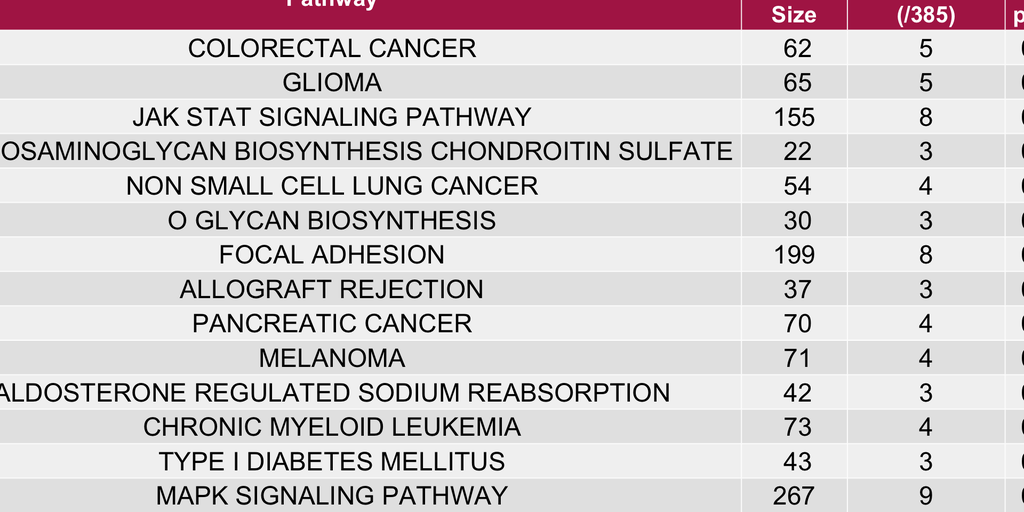

```r
#get column as a vector
geneList<- c(newpeakAnno$geneId, newpeakAnno$A, newpeakAnno$B, newpeakAnno$C, newpeakAnno$D, newpeakAnno$E, newpeakAnno$F, newpeakAnno$G, newpeakAnno$H, newpeakAnno$I)

#remove NAs
geneList <- geneList[!is.na(geneList)]

#remove duplicates
geneList <- unique(geneList)

spibRes <- enricher(geneList,
                    #Use pathways in term2gene
                    TERM2GENE=term2gene,
                    #no cutoffs on reported results, we want to see all results and p values
                    minGSSize = 0,
                    maxGSSize = 1000,
                    pvalueCutoff = 1,
                    qvalueCutoff = 1)


#get dataframe of results
spibRes.df <- fortify(spibRes,
              showCategory = length(unique(term2gene$term)), #show all pathways tested
              split=NULL)

resTab.spib <-
  mutate(spibRes.df, genesetSize = BgRatio*length(unique(term2gene$gene))) %>%  #multiply BgRatio by total genes tested to get number of genes in set
  dplyr::select(ID, pvalue, Count, genesetSize)

colnames(resTab.spib) <- c("ID", "pvalue_SPIB","count_SPIB", "genesetSize")


resTab <- resTab.spib

#where count and p value is NA, put a 0 / 1 (ie there were no SPIB target genes in the set)
resTab$count_SPIB[is.na(resTab$count_SPIB)] <- 0

resTab$pvalue_SPIB[is.na(resTab$pvalue_SPIB)] <- 1

#select columns of interest to show in figure
resTab <- dplyr::select(resTab, ID, genesetSize,  count_SPIB, pvalue_SPIB)

#adjust decimal places of p values
resTab$pvalue_SPIB <- round(resTab$pvalue_SPIB, digits = 3)

#get significant results
resTab <- dplyr::filter(resTab, pvalue_SPIB<0.05)

colnames(resTab) <- c("Pathway",

                      "Geneset\nSize",

                      #show the total number of SPIB targets in ChIPseq data
                      paste("Spi-B targets\n(/" ,length(geneList),")", sep= ""),
                      "SPIB\np-value")

keggPathways_allgenes <-
ggtexttable(resTab, rows = NULL,
           theme = ttheme(
             colnames.style = colnames_style(color = "white", fill = palreds[7], size = 16),
             tbody.style = tbody_style(color = "black",size = 18)
           )
)


keggPathways_allgenes
```